# Studying Infrastructure Development and Economic Growth in Rural India

Aditya Sarkar and Mohammed Zahir Ali

08/05/2023

#### Importing the required libraries

```r
library(knitr)
library(tidyverse)
library(ggplot2)
library(ggthemes)
library(ggrepel)
library(stargazer)
library(sf)
library(viridis)
library(stringdist)
library(rvest)
library(stringr)
library(lubridate)
library(psych)
library(corrplot)
library(factoextra)  # for visualization
library(caret)       # for data preprocessing
library(stats)       # for PCA function
library(VIM)
```

#### Importing the datasets

We are using datasets from SHRUG. Namely, the following datasets have been used:

- Primary Census (2011)
- Economic Census (2013)
- Socioeconomic and Caste Census (2012)
- Night Lights Dataset

```r
roads = read.csv('csv_shrug-v1.5.samosa-ancillary-csv/shrug-v1.5.samosa-ancillary-csv/shrug_ancillary.csv', stringsAsFactors = F)
nl = read.csv('csv_shrug-v1.5.samosa-nl-csv/shrug-v1.5.samosa-nl-csv/shrug_nl_wide.csv', stringsAsFactors = F)
pc = read.csv('csv_shrug-v1.5.samosa-pop-econ-census-csv/shrug-v1.5.samosa-pop-econ-census-csv/shrug_pc11.csv', stringsAsFactors = F)
ec = read.csv('csv_shrug-v1.5.samosa-pop-econ-census-csv/shrug-v1.5.samosa-pop-econ-census-csv/shrug_ec.csv', stringsAsFactors = F)
secc = read.csv('csv_shrug-v1.5.samosa-secc-csv/shrug-v1.5.samosa-secc-csv/shrug_secc.csv', stringsAsFactors = F)
```

Initially, we were also planning to use the PMGSY Roads dataset - since length of paved roads was a potential proxy for infrastructure development in rural areas. But given that we are predominantly working with census data from 2011 and 2013, we needed to limit out analysis from other datasets to that point in time.

```r
glimpse(roads)
```

```
## Rows: 590,855
## Columns: 22
## $ shrid                   <chr> "11-01-000001", "11-01-000002", "11-01-000005"…
## $ tdist_10                <dbl> 23.4784100, 21.8980000, 13.9811400, 10.4245700…
## $ tdist_50                <dbl> 69.29648, 68.30957, 58.10366, 53.62597, 50.566…
## $ tdist_100               <dbl> 120.32990, 119.88600, 108.18570, 103.71920, 99…
## $ tdist_500               <dbl> 120.32990, 119.88600, 108.18570, 103.71920, 99…
## $ thiessen_polygon        <chr> "", "", "", "", "", "", "", "", "", "", "", ""…
## $ road_award_date_new     <chr> "24oct2006", "24oct2006", "24oct2006", "", "20…
## $ road_award_date_upg     <chr> "", "", "", "", "", "", "", "", "", "", "", ""…
## $ road_comp_date_new      <chr> "01jun2010", "01jun2010", "01jun2010", "", "",…
## $ road_comp_date_upg      <chr> "", "", "", "", "", "", "", "", "", "", "", ""…
## $ road_comp_date_stip_new <chr> "07nov2007", "07nov2007", "07nov2007", "", "",…
## $ road_comp_date_stip_upg <chr> "", "", "", "", "", "", "", "", "", "", "", ""…
## $ road_sanc_year_new      <int> 2004, 2004, 2004, NA, 2007, 2007, NA, NA, NA, …
## $ road_sanc_year_upg      <int> NA, NA, NA, NA, NA, NA, NA, NA, NA, NA, NA, NA…
## $ road_length_new         <dbl> 5.5, 5.5, 5.5, NA, NA, NA, NA, NA, NA, NA, NA,…
## $ road_length_upg         <dbl> NA, NA, NA, NA, NA, NA, NA, NA, NA, NA, NA, NA…
## $ road_cost_new           <dbl> 170.10, 170.10, 170.10, NA, NA, NA, NA, NA, NA…
## $ road_cost_upg           <dbl> NA, NA, NA, NA, NA, NA, NA, NA, NA, NA, NA, NA…
## $ road_cost_sanc_new      <dbl> 181.71, 181.71, 181.71, NA, NA, NA, NA, NA, NA…
## $ road_cost_sanc_upg      <dbl> NA, NA, NA, NA, NA, NA, NA, NA, NA, NA, NA, NA…
## $ road_cost_state_new     <dbl> 0, 0, 0, NA, NA, NA, NA, NA, NA, NA, NA, NA, N…
## $ road_cost_state_upg     <dbl> NA, NA, NA, NA, NA, NA, NA, NA, NA, NA, NA, NA…
```

But the date variables in the Roads dataset had a lot of missing values, rendering it difficult to isolate the datapoints of interest. We therefore do not use this dataset for further analysis.

From the Economic Census, and the Night Lights dataset, we only keep the variables from 2013.

```r
ec = ec %>%
  select(shrid, ec13_emp_all, ec13_emp_manuf, ec13_emp_services)

nl = nl %>%
  select(shrid, num_cells, total_light2013, total_light_cal2013)
```

We can now have a look at how many data points we have across all our datasets.

```r
cat(paste("ec:", nrow(ec), "rows x", ncol(ec), "columns |",
          "nl:", nrow(nl), "rows x", ncol(nl), "columns |",
          "pc:", nrow(pc), "rows x", ncol(pc), "columns |",
          "secc:", nrow(secc), "rows x", ncol(secc), "columns |"))
```

```
## ec: 584402 rows x 4 columns | nl: 572017 rows x 4 columns | pc: 590874 rows x 33 columns | secc: 565991 rows x 11 columns |
```

Since we will be using SHRIDs as common keys for merging, we need to filter the datasets to the SHRIDs that are common across all datasets.

```r
common_shrids = Reduce(intersect, lapply(list(ec$shrid, nl$shrid, pc$shrid, secc$shrid), unique))

# Subset each dataset using common SHRIDs

ec = subset(ec, shrid %in% common_shrids)
nl = subset(nl, shrid %in% common_shrids)
pc = subset(pc, shrid %in% common_shrids)
secc = subset(secc, shrid %in% common_shrids)
```

Let us now have a look at the number of rows after subsetting the datasets to common SHRIDs.

```
## ec: 515462 rows x 4 columns | nl: 515462 rows x 4 columns | pc: 515462 rows x 33 columns | secc: 515462 rows x 11 columns |
```

We then aggregate the metrics for Education (number of educational institutions), Power Supply (across summer and winter months for all use cases), and average Night Light.

```r
pc = pc %>%
  mutate(num_edu = pc11_vd_p_sch + pc11_vd_s_sch + pc11_vd_m_sch + pc11_vd_s_s_sch + pc11_vd_college) %>%
  mutate(mean_power_supply = (pc11_vd_power_all_sum + pc11_vd_power_all_win)/2)

nl = nl %>%
  mutate(lights = total_light_cal2013/num_cells)

head(pc %>% select(shrid, num_edu, mean_power_supply)) %>% knitr::kable()
```

|  | shrid | num_edu | mean_power_supply |
| --- | --- | --- | --- |
| 2 | 11-01-000002 | 7 | 7 |
| 3 | 11-01-000005 | 8 | 6 |
| 4 | 11-01-000006 | 5 | 7 |
| 5 | 11-01-000007 | 6 | 7 |
| 7 | 11-01-000009 | 5 | 7 |
| 8 | 11-01-000010 | 10 | 7 |

```r
head(nl) %>% knitr::kable()
```

|  | shrid | num_cells | total_light2013 | total_light_cal2013 | lights |
| --- | --- | --- | --- | --- | --- |
| 2 | 11-01-000002 | 9 | 10 | 24 | 2.666667 |
| 5 | 11-01-000005 | 6 | 0 | 12 | 2.000000 |
| 6 | 11-01-000006 | 7 | 0 | 14 | 2.000000 |
| 7 | 11-01-000007 | 4 | 0 | 8 | 2.000000 |
| 9 | 11-01-000009 | 7 | 0 | 14 | 2.000000 |
| 10 | 11-01-000010 | 8 | 5 | 19 | 2.375000 |

We merge the PC and SECC dataset to create a metric for agricultural employment.

```r
pc_secc = left_join(pc, secc, by = 'shrid')

# Create a mean of number of members per household for both urban and rural

pc_secc$hh_size_mean = ifelse(is.na(pc_secc$num_members_mean_rural) & !is.na(pc_secc$num_members_mean_urban), pc_secc$num_members_mean_urban,
                              ifelse(is.na(pc_secc$num_members_mean_urban) & !is.na(pc_secc$num_members_mean_rural), pc_secc$num_members_mean_rural,
                                     ifelse(!is.na(pc_secc$num_members_mean_rural) & !is.na(pc_secc$num_members_mean_urban), mean(c(pc_secc$num_members_mean_rural, pc_secc$num_members_mean_urban)),
                                            NA)))

# Drop the rows which have NA for the final Household size column

pc_secc = pc_secc[complete.cases(pc_secc$hh_size_mean),]

glimpse(pc_secc$hh_size_mean)
```

```
##  num [1:513098] 6.24 7.1 6.67 6.97 5.82 ...
```

Derive the agricultural employment variable based on number of households, mean household size, and an estimate of how many members per household would be involved in agriculture(2).

```r
pc_secc = pc_secc %>%
  mutate(agr_emp = (secc_inc_cultiv_share * pc11_pca_no_hh * hh_size_mean)/2)

# Drop NA rows for this new column and subset all datasets again

pc_secc = pc_secc[complete.cases(pc_secc$agr_emp),]
glimpse(pc_secc$agr_emp)
```

```
##  num [1:491011] 16.42 44.55 176.8 5.74 88.1 ...
```

```r
# Merge EC into this to get non-farm employment figures

pc_secc_ec = left_join(pc_secc, ec, by = 'shrid')

# Create a new column using the consumption figures from SECC dataset (mean of urban and rural)

pc_secc_ec$consumption = ifelse(is.na(pc_secc_ec$secc_cons_pc_rural) & !is.na(pc_secc_ec$secc_cons_pc_urban), pc_secc_ec$secc_cons_pc_urban,
                              ifelse(is.na(pc_secc_ec$secc_cons_pc_urban) & !is.na(pc_secc_ec$secc_cons_pc_rural), pc_secc_ec$secc_cons_pc_rural,
                                     ifelse(!is.na(pc_secc_ec$secc_cons_pc_rural) & !is.na(pc_secc_ec$secc_cons_pc_urban), mean(c(pc_secc_ec$secc_cons_pc_rural, pc_secc_ec$secc_cons_pc_urban)),
                                            NA)))

# Drop NA rows for this new column and subset all datasets

pc_secc_ec = pc_secc_ec[complete.cases(pc_secc_ec$consumption),]
```

```r
# Create a new column for poverty rate (PPP) - based on mean of urban and rural

pc_secc_ec$PPP = ifelse(is.na(pc_secc_ec$secc_pov_rate_rural) & !is.na(pc_secc_ec$secc_pov_rate_urban), pc_secc_ec$secc_pov_rate_urban,
                                ifelse(is.na(pc_secc_ec$secc_pov_rate_urban) & !is.na(pc_secc_ec$secc_pov_rate_rural), pc_secc_ec$secc_pov_rate_rural,
                                       ifelse(!is.na(pc_secc_ec$secc_pov_rate_rural) & !is.na(pc_secc_ec$secc_pov_rate_urban), mean(c(pc_secc_ec$secc_pov_rate_rural, pc_secc_ec$secc_pov_rate_urban)),
                                              NA)))

# Drop NA rows from this new PPP column and subset all datasets

pc_secc_ec = pc_secc_ec[complete.cases(pc_secc_ec$PPP),]

# Add NL figures to this dataset to create the final dataset.

pc_secc_ec_nl = left_join(pc_secc_ec, nl, by='shrid')
```

```r
# Create a new dataset with the aggregated columns which will serve as proxies for our IV and DV

final_corr = pc_secc_ec_nl %>%
  select(shrid, pc11_pca_tot_p, hh_size_mean, pc11_vd_area, num_edu, mean_power_supply, agr_emp, ec13_emp_all, consumption, PPP, lights)

# Normalize the sum variables based on 1k population

final_corr = final_corr %>%
  mutate(edu_norm = num_edu/((pc11_pca_tot_p)/1000),
         agr_emp_norm = agr_emp/((pc11_pca_tot_p)/1000),
         ec13_emp_all_norm = ec13_emp_all/((pc11_pca_tot_p)/1000))

final_corr = na.omit(final_corr)

glimpse(final_corr)
```

```
## Rows: 431,071
## Columns: 14
## $ shrid             <chr> "11-01-000002", "11-01-000005", "11-01-000006", "11-…
## $ pc11_pca_tot_p    <dbl> 3770, 5255, 3001, 1310, 3080, 4437, 2227, 2197, 1996…
## $ hh_size_mean      <dbl> 6.241497, 7.101151, 6.672613, 6.968893, 5.824985, 7.…
## $ pc11_vd_area      <dbl> 237.55, 355.30, 146.50, 130.30, 459.70, 385.30, 326.…
## $ num_edu           <int> 7, 8, 5, 6, 5, 10, 7, 4, 2, 5, 9, 5, 17, 3, 18, 11, …
## $ mean_power_supply <dbl> 7.0, 6.0, 7.0, 7.0, 7.0, 7.0, 7.0, 7.0, 7.0, 7.0, 10…
## $ agr_emp           <dbl> 16.424999, 44.547463, 176.804268, 5.739134, 88.09947…
## $ ec13_emp_all      <int> 49, 82, 43, 47, 31, 30, 46, 37, 26, 74, 167, 82, 195…
## $ consumption       <dbl> 13509.520, 8611.758, 9498.939, 11964.710, 10137.010,…
## $ PPP               <dbl> 0.477891, 0.776421, 0.730325, 0.530650, 0.681202, 0.…
## $ lights            <dbl> 2.666667, 2.000000, 2.000000, 2.000000, 2.000000, 2.…
## $ edu_norm          <dbl> 1.8567639, 1.5223597, 1.6661113, 4.5801527, 1.623376…
## $ agr_emp_norm      <dbl> 4.3567636, 8.4771576, 58.9151176, 4.3810185, 28.6037…
## $ ec13_emp_all_norm <dbl> 12.997347, 15.604186, 14.328557, 35.877863, 10.06493…
```

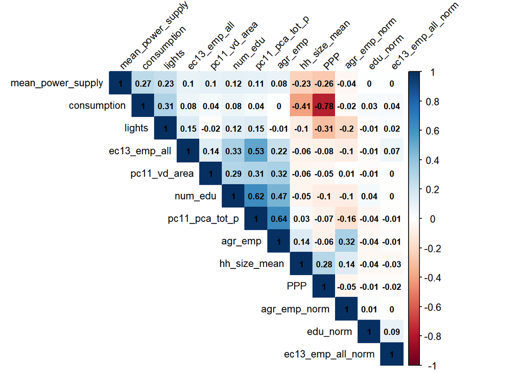

```r
# Create a correlation matrix after dropping shrid column
final_corr_matrix = cor(final_corr[, -1])

corrplot(final_corr_matrix, method = "color", addCoef.col = "black",
         type = "upper", order = "hclust", tl.col = "black",
         tl.srt = 45, number.cex=0.7, tl.cex = 0.8)
```

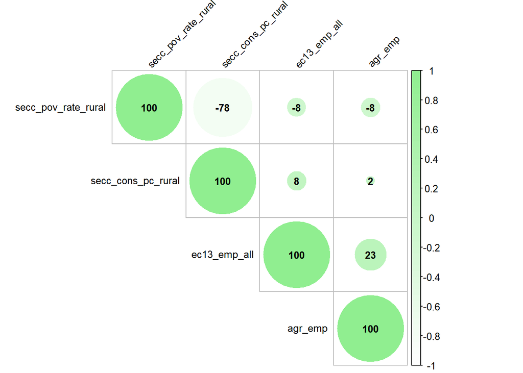

```r
Y_vars = pc_secc_ec_nl %>%
  select(ec13_emp_all, agr_emp, secc_cons_pc_rural, secc_pov_rate_rural)
Y_vars = na.omit(Y_vars)
Y_vars_corr = cor(Y_vars)

corrplot(Y_vars_corr, type = "upper", order = "hclust",
         tl.col = "black", tl.srt = 45,
         tl.cex = 0.8, method = "circle", number.cex = 0.8,
         addCoef.col = "black", addCoefasPercent = TRUE,
         col = colorRampPalette(c("white", "lightgreen"))(50))
```

```r
pca_data = pc_secc_ec_nl %>%
  select(shrid, pc11_pca_tot_p, pc11_pca_tot_p_r, pc11_pca_no_hh, pc11_pca_p_lit, pc11_vd_p_sch, pc11_vd_m_sch, pc11_vd_s_sch, pc11_vd_s_s_sch, pc11_vd_college, pc11_vd_power_all_sum, pc11_vd_power_all_win, lights)

state_keys = read.csv('csv_shrug-v1.5.samosa-pop-econ-census-csv/shrug-v1.5.samosa-keys-csv/shrug_pc11_state_key.csv')

pca_data = na.omit(pca_data)

pca_data_states = left_join(pca_data, state_keys, by = 'shrid')

# Filter for BIMARU states
pca_data_bimaru = pca_data_states %>%
  filter(pc11_state_name == 'bihar' | pc11_state_name == 'madhya pradesh' | pc11_state_name == 'rajasthan' | pc11_state_name == 'uttar pradesh') %>%
  select(-shrid, -pc11_state_id, -pc11_state_name)

pca_data_bimaru = na.omit(pca_data_bimaru)

pca_data_corr_bimaru = cor(pca_data_bimaru)
```

Create a correlation heatmap of the dataset before PCA to check multicollinearity.

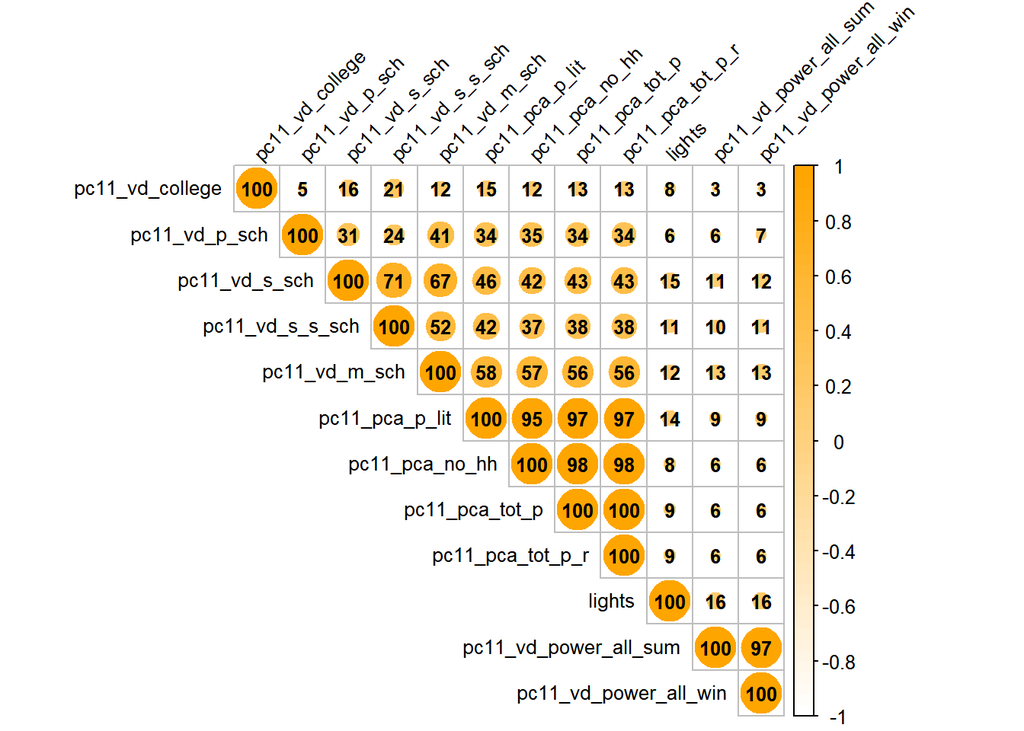

```r
corrplot(pca_data_corr_bimaru, type = "upper", order = "hclust",
         tl.col = "black", tl.srt = 45,
         tl.cex = 0.8, method = "circle", number.cex = 0.8,
         addCoef.col = "black", addCoefasPercent = TRUE,
         col = colorRampPalette(c("white", "orange"))(50))
```

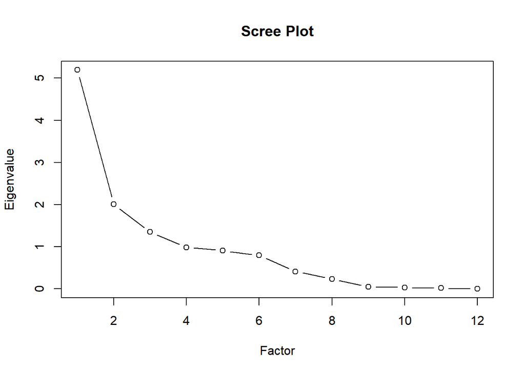

```r
# Fit the factor model and extract the eigenvalues
model_bimaru = principal(pca_data_bimaru, nfactors = ncol(pca_data_bimaru), rotate = "none")
eigenvalues_bimaru = model_bimaru$values

# Plot the scree plot
plot(eigenvalues_bimaru, type = "b", xlab = "Factor", ylab = "Eigenvalue",
     main = "Scree Plot")
```

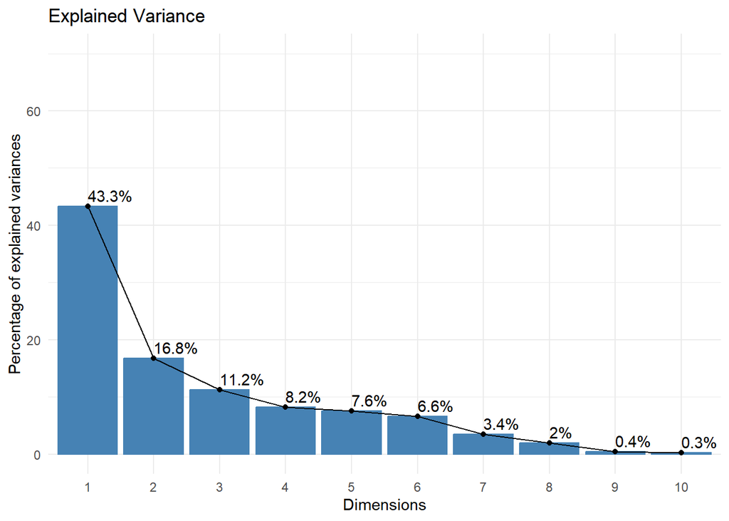

```r
#PC Analysis
pc_bimaru = prcomp(pca_data_bimaru, scale. = TRUE)

# Visualize explained variance
fviz_eig(pc_bimaru, addlabels = TRUE, ylim = c(0, 70)) +
  theme_minimal() +
  ggtitle("Explained Variance")
```

We can see that the first 4 PCs explain most of the variance in the dataset, so we only consider these PCs for further analysis.

```r
# Extract the PC loadings and scores
loadings_bimaru <- pc_bimaru$rotation
scores_bimaru <- pc_bimaru$x

scores_bimaru <- scores_bimaru[, 0:4] # Only take the first 4 PCs
```

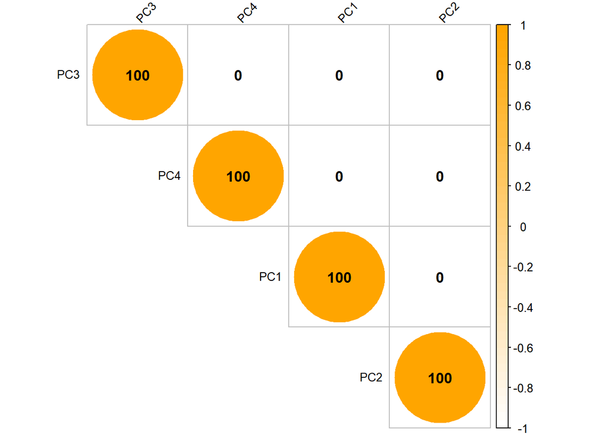

```r
pc_scores_corr_bimaru <- cor(scores_bimaru)

# Create a correlation heatmap of the scores after PCA
corrplot(pc_scores_corr_bimaru, type = "upper", order = "hclust",
         tl.col = "black", tl.srt = 45,
         tl.cex = 0.8, method = "circle",
         addCoef.col = "black", addCoefasPercent = TRUE,
         col = colorRampPalette(c("white", "orange"))(50))
```

We can now see that there is no multicollinearity because all Principal Components are orthogonal to one another.

Next we run a multiple linear regression with scores of the PCA as predictors and Y as a metric of economic growth.

```r
Y = left_join(pca_data_bimaru, pc_secc_ec_nl, by = 'shrid')
mlr_data <- data.frame(scores_bimaru, Y$secc_pov_rate_tend_rural)
model <- lm(Y.secc_pov_rate_tend_rural ~ ., data = mlr_data)
summary(model)
```

```
##
## Call:
## lm(formula = Y.secc_pov_rate_tend_rural ~ ., data = mlr_data)
##
## Residuals:
##      Min       1Q   Median       3Q      Max
## -1.75608 -0.12771 -0.02252  0.09981  0.78481
##
## Coefficients:
##               Estimate Std. Error t value Pr(>|t|)
## (Intercept)  0.2892717  0.0004076  709.75   <2e-16 ***
## PC1         -0.0068664  0.0001788  -38.40   <2e-16 ***
## PC2          0.0118494  0.0002874   41.22   <2e-16 ***
## PC3         -0.0046158  0.0003510  -13.15   <2e-16 ***
## PC4         -0.0190071  0.0004105  -46.31   <2e-16 ***
## ---
## Signif. codes:  0 '***' 0.001 '**' 0.01 '*' 0.05 '.' 0.1 ' ' 1
##
## Residual standard error: 0.1786 on 191914 degrees of freedom
## Multiple R-squared:  0.02782,    Adjusted R-squared:  0.0278
## F-statistic:  1373 on 4 and 191914 DF,  p-value: < 2.2e-16
```

##### Consumption

```r
Y = left_join(pca_data_bimaru, pc_secc_ec_nl, by = 'shrid')
mlr_data <- data.frame(scores_bimaru, Y$secc_cons_pc_rural)
model <- lm(Y.secc_cons_pc_rural ~ ., data = mlr_data)
summary(model)
```

```
##
## Call:
## lm(formula = Y.secc_cons_pc_rural ~ ., data = mlr_data)
##
## Residuals:
##    Min     1Q Median     3Q    Max
## -14983  -2746   -738   1722 213230
##
## Coefficients:
##              Estimate Std. Error  t value Pr(>|t|)
## (Intercept) 16070.846     12.572 1278.292   <2e-16 ***
## PC1            49.798      5.516    9.027   <2e-16 ***
## PC2          -424.541      8.866  -47.882   <2e-16 ***
## PC3           299.291     10.826   27.647   <2e-16 ***
## PC4           382.011     12.661   30.172   <2e-16 ***
## ---
## Signif. codes:  0 '***' 0.001 '**' 0.01 '*' 0.05 '.' 0.1 ' ' 1
##
## Residual standard error: 5508 on 191914 degrees of freedom
## Multiple R-squared:  0.02066,    Adjusted R-squared:  0.02064
## F-statistic:  1012 on 4 and 191914 DF,  p-value: < 2.2e-16
```

##### Agricultural Employment

```r
Y = left_join(pca_data_bimaru, pc_secc_ec_nl, by = 'shrid')
mlr_data <- data.frame(scores_bimaru, Y$agr_emp)
model <- lm(Y.agr_emp ~ ., data = mlr_data)
summary(model)
```

```
##
## Call:
## lm(formula = Y.agr_emp ~ ., data = mlr_data)
##
## Residuals:
##     Min      1Q  Median      3Q     Max
## -7011.2  -126.2   -46.2    87.1  5932.8
##
## Coefficients:
##             Estimate Std. Error t value Pr(>|t|)
## (Intercept) 321.6242     0.6424  500.67   <2e-16 ***
## PC1         110.6081     0.2819  392.41   <2e-16 ***
## PC2          28.4804     0.4530   62.87   <2e-16 ***
## PC3         -60.6970     0.5531 -109.73   <2e-16 ***
## PC4         -16.3364     0.6469  -25.25   <2e-16 ***
## ---
## Signif. codes:  0 '***' 0.001 '**' 0.01 '*' 0.05 '.' 0.1 ' ' 1
##
## Residual standard error: 281.4 on 191914 degrees of freedom
## Multiple R-squared:  0.4706, Adjusted R-squared:  0.4706
## F-statistic: 4.265e+04 on 4 and 191914 DF,  p-value: < 2.2e-16
```

##### Non-farm Employment

```r
Y = left_join(pca_data_bimaru, pc_secc_ec_nl, by = 'shrid')
mlr_data <- data.frame(scores_bimaru, Y$ec13_emp_all)
model <- lm(Y.ec13_emp_all ~ ., data = mlr_data)
summary(model)
```

```
##
## Call:
## lm(formula = Y.ec13_emp_all ~ ., data = mlr_data)
##
## Residuals:
##     Min      1Q  Median      3Q     Max
## -1578.3   -30.0    -3.4    16.2 10483.8
##
## Coefficients:
##             Estimate Std. Error t value Pr(>|t|)
## (Intercept)  56.0078     0.2896  193.37   <2e-16 ***
## PC1          37.8023     0.1249  302.66   <2e-16 ***
## PC2          -3.3491     0.2019  -16.59   <2e-16 ***
## PC3           2.0597     0.2429    8.48   <2e-16 ***
## PC4          12.8391     0.2842   45.18   <2e-16 ***
## ---
## Signif. codes:  0 '***' 0.001 '**' 0.01 '*' 0.05 '.' 0.1 ' ' 1
##
## Residual standard error: 121.8 on 177338 degrees of freedom
##   (14576 observations deleted due to missingness)
## Multiple R-squared:  0.3466, Adjusted R-squared:  0.3466
## F-statistic: 2.352e+04 on 4 and 177338 DF,  p-value: < 2.2e-16
```

#### Rerun PCA for Rest of India (non BIMARU)

```r
pca_data_roi = pca_data_states %>%
  filter(pc11_state_name != 'bihar' & pc11_state_name != 'madhya pradesh' & pc11_state_name != 'rajasthan' & pc11_state_name != 'uttar pradesh') %>%
  select(-shrid, -pc11_state_id, -pc11_state_name)

pca_data_roi = na.omit(pca_data_roi)

pca_data_corr_roi = cor(pca_data_roi)
```

Create a correlation heatmap of the dataset before PCA to check multicollinearity.

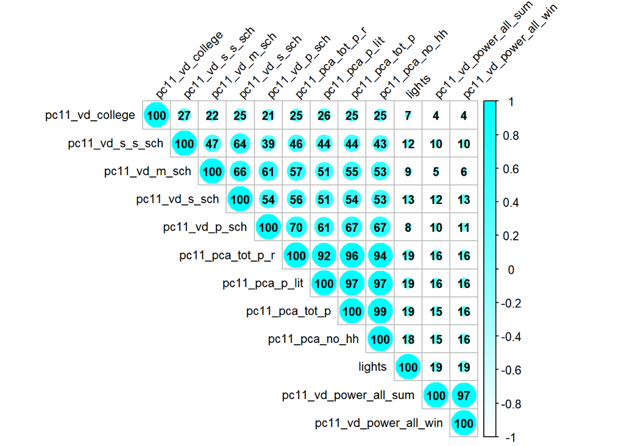

```r
corrplot(pca_data_corr_roi, type = "upper", order = "hclust",
         tl.col = "black", tl.srt = 45,
         tl.cex = 0.8, method = "circle", number.cex = 0.8,
         addCoef.col = "black", addCoefasPercent = TRUE,
         col = colorRampPalette(c("white", "cyan"))(50))
```

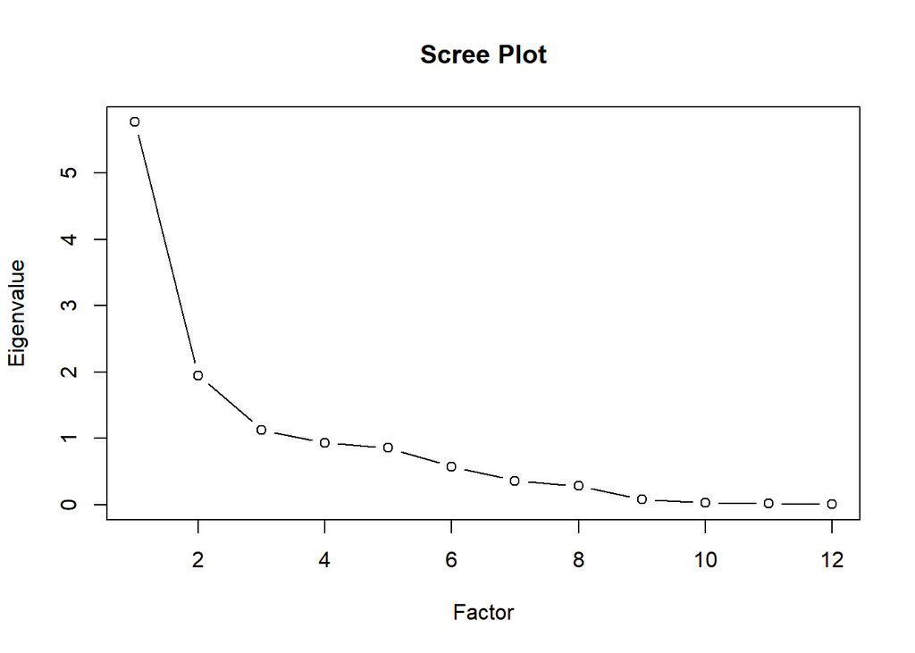

```r
# Fit the factor model and extract the eigenvalues
model_roi = principal(pca_data_roi, nfactors = ncol(pca_data_roi), rotate = "none")
eigenvalues_roi = model_roi$values

# Plot the scree plot
plot(eigenvalues_roi, type = "b", xlab = "Factor", ylab = "Eigenvalue",
     main = "Scree Plot")
```

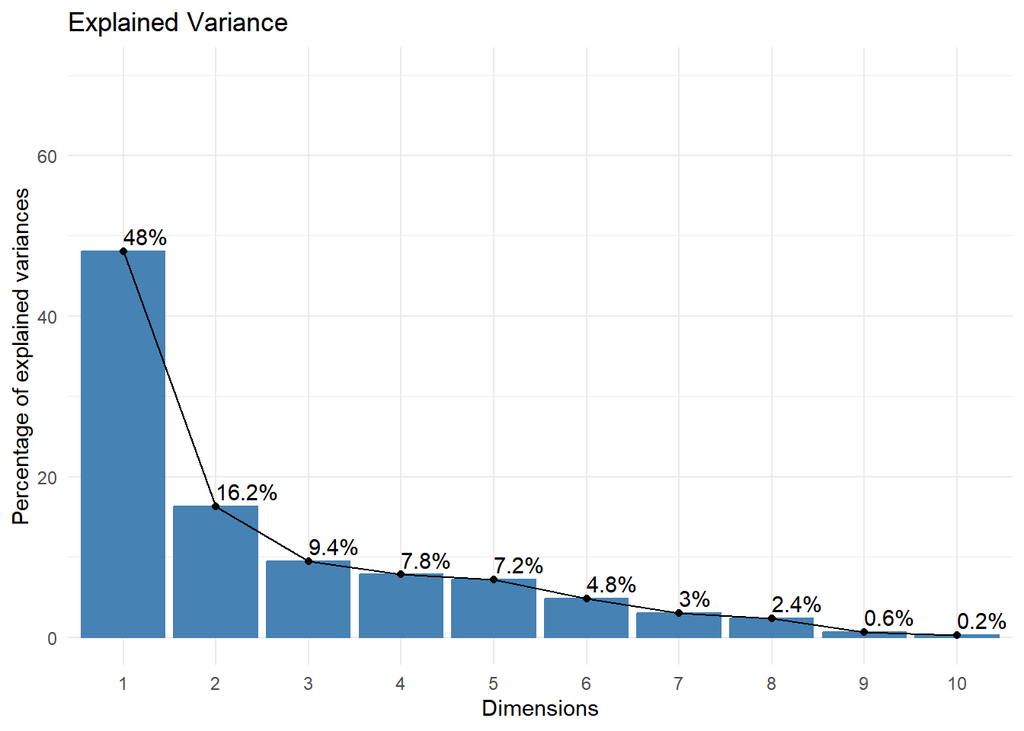

```r
#PC Analysis
pc_roi = prcomp(pca_data_roi, scale. = TRUE)

# Visualize explained variance
fviz_eig(pc_roi, addlabels = TRUE, ylim = c(0, 70)) +
  theme_minimal() +
  ggtitle("Explained Variance")
```

We can see that the first 4 PCs explain most of the variance in the dataset so we only limit our analysis to these 4 PCs.

```r
# Extract the PC loadings and scores
loadings_roi <- pc_roi$rotation
scores_roi <- pc_roi$x
scores_roi <- scores_roi[, 0:4] # Only take the first 4 PCs
```

Create a correlation heatmap of the scores after PCA - to ensure that the PCs are orthogonal and that there is no multicollinearity.

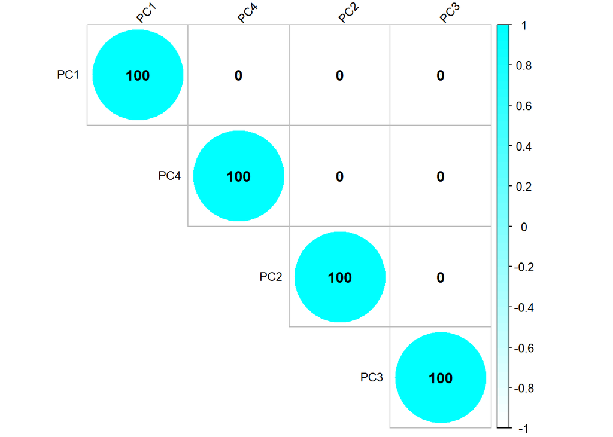

```r
pc_scores_corr_roi <- cor(scores_roi)

corrplot(pc_scores_corr_roi, type = "upper", order = "hclust",
         tl.col = "black", tl.srt = 45,
         tl.cex = 0.8, method = "circle",
         addCoef.col = "black", addCoefasPercent = TRUE,
         col = colorRampPalette(c("white", "cyan"))(50))
```

We can now see that there is no multicollinearity because all Principal Components are orthogonal to one another.

Next we run a multiple linear regression with scores of the PCA as predictors and Y as a metric of economic growth.

##### Poverty Rate (PPP)

```r
Y = left_join(pca_data_roi, pc_secc_ec_nl, by = 'shrid')
mlr_data <- data.frame(scores_roi, Y$secc_pov_rate_rural)
model <- lm(Y.secc_pov_rate_rural ~ ., data = mlr_data)
summary(model)
```

```
##
## Call:
## lm(formula = Y.secc_pov_rate_rural ~ ., data = mlr_data)
##
## Residuals:
##     Min      1Q  Median      3Q     Max
## -0.4225 -0.1625 -0.0308  0.1424  2.3868
##
## Coefficients:
##               Estimate Std. Error t value Pr(>|t|)
## (Intercept)  0.3082572  0.0004017  767.32   <2e-16 ***
## PC1          0.0136202  0.0001673   81.39   <2e-16 ***
## PC2         -0.0403804  0.0002877 -140.36   <2e-16 ***
## PC3          0.0075227  0.0003778   19.91   <2e-16 ***
## PC4         -0.0441758  0.0004156 -106.30   <2e-16 ***
## ---
## Signif. codes:  0 '***' 0.001 '**' 0.01 '*' 0.05 '.' 0.1 ' ' 1
##
## Residual standard error: 0.2075 on 266679 degrees of freedom
## Multiple R-squared:  0.1248, Adjusted R-squared:  0.1248
## F-statistic:  9505 on 4 and 266679 DF,  p-value: < 2.2e-16
```

##### Consumption

```r
Y = left_join(pca_data_roi, pc_secc_ec_nl, by = 'shrid')
mlr_data <- data.frame(scores_roi, Y$secc_cons_pc_rural)
model <- lm(Y.secc_cons_pc_rural ~ ., data = mlr_data)
summary(model)
```

```
##
## Call:
## lm(formula = Y.secc_cons_pc_rural ~ ., data = mlr_data)
##
## Residuals:
##    Min     1Q Median     3Q    Max
## -81766  -3709   -789   2743 228321
##
## Coefficients:
##              Estimate Std. Error t value Pr(>|t|)
## (Intercept) 18206.308     11.910 1528.69   <2e-16 ***
## PC1          -346.997      4.961  -69.95   <2e-16 ***
## PC2          1259.210      8.529  147.64   <2e-16 ***
## PC3          -316.654     11.199  -28.27   <2e-16 ***
## PC4          1459.402     12.321  118.45   <2e-16 ***
## ---
## Signif. codes:  0 '***' 0.001 '**' 0.01 '*' 0.05 '.' 0.1 ' ' 1
##
## Residual standard error: 6150 on 266679 degrees of freedom
## Multiple R-squared:  0.1347, Adjusted R-squared:  0.1347
## F-statistic: 1.038e+04 on 4 and 266679 DF,  p-value: < 2.2e-16
```

##### Agricultural Employment

```r
Y = left_join(pca_data_roi, pc_secc_ec_nl, by = 'shrid')
mlr_data <- data.frame(scores_roi, Y$agr_emp)
model <- lm(Y.agr_emp ~ ., data = mlr_data)
summary(model)
```

```
##
## Call:
## lm(formula = Y.agr_emp ~ ., data = mlr_data)
##
## Residuals:
##      Min       1Q   Median       3Q      Max
## -13532.6   -134.5    -51.6     78.6  20349.7
##
## Coefficients:
##              Estimate Std. Error  t value Pr(>|t|)
## (Intercept)  279.1923     0.5799  481.437  < 2e-16 ***
## PC1         -100.3837     0.2416 -415.572  < 2e-16 ***
## PC2           -3.3048     0.4153   -7.958 1.76e-15 ***
## PC3           41.3205     0.5453   75.776  < 2e-16 ***
## PC4          -59.3242     0.5999  -98.885  < 2e-16 ***
## ---
## Signif. codes:  0 '***' 0.001 '**' 0.01 '*' 0.05 '.' 0.1 ' ' 1
##
## Residual standard error: 299.5 on 266679 degrees of freedom
## Multiple R-squared:  0.4138, Adjusted R-squared:  0.4138
## F-statistic: 4.707e+04 on 4 and 266679 DF,  p-value: < 2.2e-16
```

##### Non-farm Employment

```r
Y = left_join(pca_data_roi, pc_secc_ec_nl, by = 'shrid')
mlr_data <- data.frame(scores_roi, Y$ec13_emp_all)
model <- lm(Y.ec13_emp_all ~ ., data = mlr_data)
summary(model)
```

```
##
## Call:
## lm(formula = Y.ec13_emp_all ~ ., data = mlr_data)
##
## Residuals:
##    Min     1Q Median     3Q    Max
##  -3398    -69     10     65 122435
##
## Coefficients:
##              Estimate Std. Error t value Pr(>|t|)
## (Intercept)  116.1550     0.8603  135.02   <2e-16 ***
## PC1         -114.5896     0.3543 -323.42   <2e-16 ***
## PC2          -14.3387     0.6173  -23.23   <2e-16 ***
## PC3           86.4504     0.7947  108.78   <2e-16 ***
## PC4           38.5573     0.8828   43.67   <2e-16 ***
## ---
## Signif. codes:  0 '***' 0.001 '**' 0.01 '*' 0.05 '.' 0.1 ' ' 1
##
## Residual standard error: 433.2 on 253723 degrees of freedom
##   (12956 observations deleted due to missingness)
## Multiple R-squared:  0.3197, Adjusted R-squared:  0.3197
## F-statistic: 2.981e+04 on 4 and 253723 DF,  p-value: < 2.2e-16
```

```r
Y = left_join(pca_data_roi, pc_secc_ec_nl, by = 'shrid')
mlr_data <- data.frame(scores_roi, Y$ec13_emp_all)
model <- lm(Y.ec13_emp_all ~ ., data = mlr_data)
summary(model)
```

```
##
## Call:
## lm(formula = Y.ec13_emp_all ~ ., data = mlr_data)
##
## Residuals:
##    Min     1Q Median     3Q    Max
##  -3398    -69     10     65 122435
##
## Coefficients:
##              Estimate Std. Error t value Pr(>|t|)
## (Intercept)  116.1550     0.8603  135.02   <2e-16 ***
## PC1         -114.5896     0.3543 -323.42   <2e-16 ***
## PC2          -14.3387     0.6173  -23.23   <2e-16 ***
## PC3           86.4504     0.7947  108.78   <2e-16 ***
## PC4           38.5573     0.8828   43.67   <2e-16 ***
## ---
## Signif. codes:  0 '***' 0.001 '**' 0.01 '*' 0.05 '.' 0.1 ' ' 1
##
## Residual standard error: 433.2 on 253723 degrees of freedom
##   (12956 observations deleted due to missingness)
## Multiple R-squared:  0.3197, Adjusted R-squared:  0.3197
## F-statistic: 2.981e+04 on 4 and 253723 DF,  p-value: < 2.2e-16
```